GeoStat Lab · M11 · Statistica spaziale

M11_N10 · Locus

# Buffer e sensibilità alla scala

5 blocchi R eseguiti1 grafico0 errori · 0 avvisiOffline · MathML

Codice, output e figure dello stesso svolgimento. Ogni notebook riparte dai dati locali ed è autonomo rispetto agli altri.

# La domanda

Come cambia una sintesi quando aumenta il raggio attorno allo stesso centro?

## Obiettivi

- Costruire appartenenze a dischi nel piano locale.
- Confrontare numerosità e medie a tre raggi.
- Riconoscere gli effetti di bordo e il supporto della media.

**Prima di iniziare.** Sono richiesti vettori, tabelle, coordinate e funzioni R di base. I blocchi vanno eseguiti in ordine; il notebook è autonomo rispetto agli altri. I calcoli usano R base e i pacchetti standard.

**Dati e unità.** 64 siti sintetici su una griglia 8 × 8, con passo 250 m e coordinate locali x_m e y_m fra 0 e 1750 m. Questo piano locale non ha un codice EPSG. La concentrazione è sintetica, in unità arbitrarie (u.a.); la quota è in metri sintetici. Ogni riga descrive un sito e il suo valore puntuale, non la media di una cella.

## Preparazione

Aprire il progetto autonomo di Locus o quello generale dei notebook. I CSV locali restano invariati. Gli output vanno in `Risultati/M11_N10/`. Nessun download o installazione viene eseguito nei blocchi.

Codice R · preparazione

```r
# Trova il modulo dal progetto autonomo o dal progetto generale dei notebook.
.gs_cerca <- normalizePath(getwd(),winslash="/",mustWork=TRUE)
repeat {
  .gs_candidati <- c(.gs_cerca,file.path(.gs_cerca,"M11_Locus"),
    file.path(.gs_cerca,"03_Notebook_svolti","M11_Locus"),
    file.path(.gs_cerca,"M11","03_Notebook_svolti","M11_Locus"))
  .gs_ok <- file.exists(file.path(.gs_candidati,"M11_N01.Rmd")) &
    file.exists(file.path(.gs_candidati,"R","funzioni_notebook.R"))
  if(any(.gs_ok)) { .gs_modulo <- .gs_candidati[which(.gs_ok)[1L]];break }
  .gs_padre <- dirname(.gs_cerca)
  if(.gs_padre==.gs_cerca) stop("Aprire il progetto M11_Locus o quello generale dei notebook.")
  .gs_cerca <- .gs_padre
}
source(file.path(.gs_modulo,"R","funzioni_notebook.R"),local=TRUE)
.gs_funzioni <- .gs_prepara_notebook(.gs_modulo,"M11_N10")
carica_dati <- .gs_funzioni$carica_dati
percorso_risultati <- .gs_funzioni$percorso_risultati
options(width=88,digits=6)
if(requireNamespace("knitr",quietly=TRUE)) {
  knitr::opts_chunk$set(echo=TRUE,error=FALSE,warning=TRUE,message=TRUE,
    fig.width=8,fig.height=5,dpi=150,fig.align="center")
}
set.seed(11010)
```

## 1. Il centro e il raggio definiscono la selezione

Il centro è (750,750)m e i raggi sono 300,600,900 m, come nel laboratorio originale. Il calcolo è euclideo nel piano locale.

Codice R · passo_01

```r
d <- carica_dati("spazio_v3.csv")
audit_spazio(d)
 centro <- c(750,750);raggi <- c(300,600,900)
 dist0 <- sqrt((d$x_m-centro[1])^2+(d$y_m-centro[2])^2)
 selezione <- sapply(raggi,function(r) dist0<=r)
 risultato <- data.frame(raggio_m=raggi,n=colSums(selezione),
   media=vapply(seq_along(raggi),function(j) mean(d$concentrazione[selezione[,j]]),numeric(1)))
 risultato
 stopifnot(all(diff(risultato$n)>=0),all(!selezione[,1]|selezione[,2]),all(!selezione[,2]|selezione[,3]))
```

Output eseguito

```
  raggio_m  n   media
1      300  5 16.7858
2      600 21 16.4486
3      900 37 16.5349
```

**Lettura del risultato.** I dischi sono annidati e il numero di siti non può diminuire. La media, invece, può aumentare o diminuire perché cambia l’insieme selezionato.

## 2. La scala cambia l’oggetto riassunto

La mappa mostra i dischi e i siti disponibili. Le parti di un disco fuori dalla griglia non contengono dati nel nostro archivio.

Codice R · passo_02

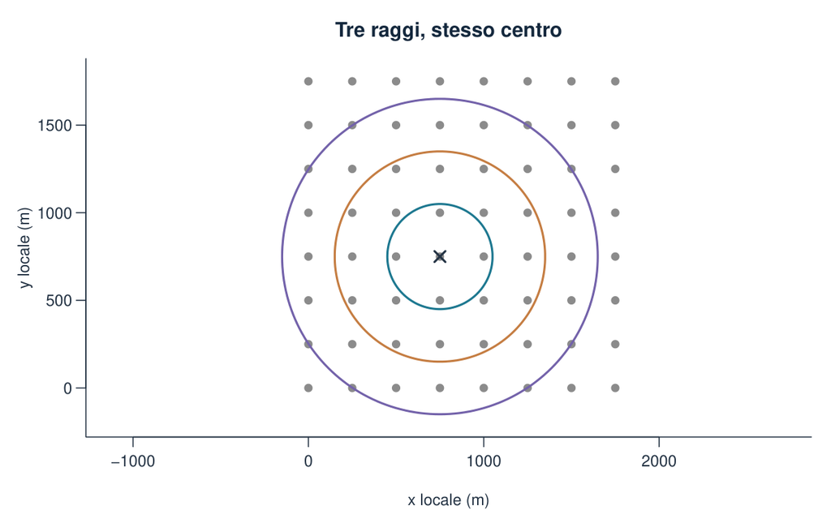

Figura 1 · Output del blocco `passo_02`. PDF vettoriale.

```r
stile_grafico()
plot(d$x_m,d$y_m,pch=19,col="grey55",asp=1,xlim=c(-200,1800),ylim=c(-200,1800),
  xlab="x locale (m)",ylab="y locale (m)",main="Tre raggi, stesso centro")
angolo <- seq(0,2*pi,length.out=201)
for(j in seq_along(raggi)) lines(centro[1]+raggi[j]*cos(angolo),
  centro[2]+raggi[j]*sin(angolo),col=palette_geo[j],lwd=2)
points(centro[1],centro[2],pch=4,cex=1.5,lwd=2)
```

**Lettura del risultato.** Il buffer geometrico non crea copertura campionaria. La media calcolata riguarda i siti selezionati e non tutte le posizioni del disco.

## 3. Esportare selezione e sintesi

La tabella di appartenenza permette di ricostruire i tre calcoli, compresi i casi esattamente sulla distanza limite.

Codice R · passo_03

```r
dettagli <- data.frame(id=d$id,distanza_dal_centro_m=dist0,
  entro300=selezione[,1],entro600=selezione[,2],entro900=selezione[,3])
write.csv(dettagli,percorso_risultati("appartenenza_buffer.csv"),row.names=FALSE)
write.csv(risultato,percorso_risultati("sintesi_buffer.csv"),row.names=FALSE)
risultato
```

Output eseguito

```
  raggio_m  n   media
1      300  5 16.7858
2      600 21 16.4486
3      900 37 16.5349
```

**Lettura del risultato.** La convenzione ≤ include il bordo. Dichiarare centro, metrica, raggio e predicato rende riproducibile il supporto della sintesi.

## Variante svolta

**Lo stesso raggio sul bordo della griglia.** Spostare il centro nell’angolo (0,0), mantenendo 600 m.

Codice R · variante

```r
dist_angolo <- sqrt(d$x_m^2+d$y_m^2)
s <- dist_angolo<=600
data.frame(centro=c("750,750","0,0"),raggio_m=600,
  n=c(sum(dist0<=600),sum(s)),
  media=c(mean(d$concentrazione[dist0<=600]),mean(d$concentrazione[s])))
```

Output eseguito

```
   centro raggio_m  n   media
1 750,750      600 21 16.4486
2     0,0      600  8 13.1514
```

La numerosità disponibile e la configurazione cambiano al bordo. Confrontare i due numeri richiede riconoscere che i siti selezionati e la copertura sono diversi.

## Errore da riconoscere

Confondere una media dei punti entro il raggio con una media areale del disco, oppure scegliere il raggio dopo aver cercato la media più favorevole.

## Risposta alla domanda

Il raggio definisce una scala di osservazione. I confronti devono conservare centro, unità, inclusione del bordo e numerosità; una selezione più ampia non garantisce automaticamente una sintesi più rappresentativa.

## Raccordo con le slide

Slide 39–40 della lezione Locus. Il notebook conserva il tema del laboratorio originale e aggiunge verifiche e una variante svolta.

## Riferimenti e provenienza

Questo svolgimento sviluppa `M11_N10` del [modulo M11 del corso](https://marzione00.github.io/Lab_Geo/#modulo-M11). Il [codice originale](https://github.com/marzione00/Lab_Geo/blob/649f7cc577b96bd1044d81e78a2f530813e4f96b/materiali/laboratori/M11/M11_N10.R) è conservato immutato in `R/Originali_corso/`; la mappa allegata documenta gli ampliamenti. Dati e originali hanno impronte SHA-256 e SHA-1 Git verificate.

Documentazione primaria delle operazioni: [R, dist](https://stat.ethz.ch/R-manual/R-devel/library/stats/html/dist.html), [R, aggregate](https://stat.ethz.ch/R-manual/R-devel/library/stats/html/aggregate.html), [R, sample](https://stat.ethz.ch/R-manual/R-devel/library/base/html/sample.html). Le definizioni spaziali e il riferimento inferenziale seguono il laboratorio originale, con le distinzioni esplicitate nel testo.